# Prep eDNA Data

Ben Best

2017-02-02

# Parse OTU

Parse:

- from OTU_table_taxa_all.txt: original tab-seperated text file in wide format (OTU rows x site columns)
- to otu.csv: comma-seperated file with zeros and other data filtered out (not having site or taxanomic identification) in long format (OTU, site rows)

```r
# setup columns for otu
otu_1 = read_tsv(otu_txt, n_max=1)
otu_cols = c(names(otu_1), 'taxa_v')

# read otu, in wide format with many 0s, and extra taxa vector column named
otu_w = read_tsv(otu_txt, col_names=otu_cols, skip=1)

# gather into long format, sparse 0s removed, column names and values expanded
otu = otu_w %>%                                                                   #   5,707 rows
  gather(sample, count, -DUP_ID, -taxa_v) %>%                                     # 291,057 rows
  filter(count > 0) %>%                                                           #  18,616 rows
  filter(!is.na(taxa_v)) %>%                                                      #   2,097 rows
  filter(
    !sample %in% c('extr_blank_1','extr_blank_2','extr_blank_3','Negative')) %>%  #   2,082 rows
  rownames_to_column('row_long') %>%
  extract(
    sample,
    c('site','moyr','replicate_ltr','replicate_num'),
    '([A-Z]{2})([0-9]{3,4})([a-z]{1})([0-9]{0,3})',
    remove=T, convert=T) %>%
  mutate(
      date = parse_date(sprintf('01%04d', moyr), '%d%m%y')) %>%
  select(-moyr) %>%
  extract(
      taxa_v,
      c('kingdom','phylum','class','order','family','genus','species'),
      "'k__(.*)','p__(.*)','c__(.*)','o__(.*)','f__(.*)','g__(.*)','s__(.*)'",
      remove=T)

write_csv(otu, otu_csv)

datatable(otu)
```

|  | row_long | DUP_ID | kingdom | phylum | class | order | family | genus | species | site | replicate_ltr | replicate_num | count | date |
| --- | --- | --- | --- | --- | --- | --- | --- | --- | --- | --- | --- | --- | --- | --- |
| 1 | 1 | OTU_1 | Eukaryota | Arthropoda | Maxillopoda | Calanoida | Clausocalanidae | Clausocalanus | Clausocalanus furcatus | MR | a |  | 5809 | 2015-04-01 |
| 2 | 2 | OTU_2 | Eukaryota | Haptophyceae | Haptophyceae | Isochrysidales | Noelaerhabdaceae | Emiliania | Emiliania huxleyi | MR | a |  | 2446 | 2015-04-01 |
| 3 | 3 | OTU_9 | Eukaryota | Haptophyceae | Haptophyceae | Isochrysidales | Noelaerhabdaceae | Emiliania | Emiliania huxleyi | MR | a |  | 786 | 2015-04-01 |
| 4 | 4 | OTU_12 | Eukaryota | Chordata | Mammalia | Primates | Hominidae | Homo | Homo sapiens | MR | a |  | 231 | 2015-04-01 |
| 5 | 5 | OTU_29 | Eukaryota | Arthropoda | Maxillopoda | Calanoida | Clausocalanidae | Clausocalanus | Clausocalanus furcatus | MR | a |  | 824 | 2015-04-01 |
| 6 | 6 | OTU_37 | Eukaryota | Annelida | Polychaeta | Phascolosomatiformes | Phascolosomatidae | Apionsoma | Apionsoma misakianum | MR | a |  | 1 | 2015-04-01 |
| 7 | 7 | OTU_39 | Eukaryota | Arthropoda | Ostracoda | Halocyprida | Halocyprididae | Euconchoecia | Euconchoecia chierchiae | MR | a |  | 1 | 2015-04-01 |
| 8 | 8 | OTU_42 | Eukaryota | Arthropoda | Maxillopoda | Calanoida | Paracalanidae | Paracalanus | Paracalanus quasimodo | MR | a |  | 284 | 2015-04-01 |
| 9 | 9 | OTU_45 | Eukaryota | Arthropoda | Branchiopoda | Diplostraca | Sididae | Penilia | Penilia avirostris | MR | a |  | 1 | 2015-04-01 |
| 10 | 10 | OTU_68 | Eukaryota | Arthropoda | Maxillopoda | Calanoida | Acartiidae | Acartia | Acartia tonsa | MR | a |  | 4 | 2015-04-01 |

[output cut: 2037 more lines]

# Data Questions

## What are the lon/lat for sites?

```r
table(otu$site, useNA='ifany')
```

```
##
##   LK   MR   WS
##  646 1013  388
```

Meanwhile using these coordinates from web search of names …

```r
sites = tribble(
  ~site_code, ~site_name,      ~lon,        ~lat,
  'MR'      , 'Molasses Reef', -81.4317097, 24.5524431,
  'LK'      , 'Looe Key',      -80.3812147, 25.0165408,
  'WS'      , 'Western Sambo', -81.713333, 24.477778)

write_csv(sites, sites_csv)

datatable(sites)
```

|  | site_code | site_name | lon | lat |
| --- | --- | --- | --- | --- |
| 1 | MR | Molasses Reef | -81.4317097 | 24.5524431 |
| 2 | LK | Looe Key | -80.3812147 | 25.0165408 |
| 3 | WS | Western Sambo | -81.713333 | 24.477778 |

```r
leaflet(sites) %>%
  addProviderTiles('Esri.OceanBasemap') %>%
  addMarkers(
    ~lon, ~lat,
    popup = ~sprintf("%s: %s", site_code, site_name))
```

[interactive chart not shown]

## Are we OK with getting rid of non-site data?

Eg columns: `extr_blank_1, extr_blank_2, extr_blank_3, Negative`

## Are we OK to skip OTUs without any identifiable taxa?

Per code above applying `filter(!is.na(taxa_v))` goes from 18,616 to 2,097 rows.

## What’s the meaning of a “t#” replicate vs others?

```r
table(otu$replicate_ltr, otu$replicate_num, useNA='ifany')
```

```
##
##      64 200 500 <NA>
##   a   0   0   0  392
##   b   0   0   0  327
##   c   0   0   0  255
##   t 369 419 285    0
```

# Taxonomic Tree

Construct phylogenetic tree using [Open Tree of Life](http://opentreeoflife.org) with R package [rotl](https://cran.r-project.org/web/packages/rotl/index.html).

## Resources

- [Phylogenetics](https://cran.r-project.org/web/views/Phylogenetics.html) | CRAN Task View

  ```r
  install.packages("ctv")
  library("ctv")
  install.views("Phylogenetics")
  ```

  - [Comparative Phylogenetics in R](https://www.r-phylo.org/wiki/HowTo/Table_of_Contents) wiki
  - [book: Analysis of Phylogenetics and Evolution with R](http://ape-package.ird.fr/APER.html) using [ape](https://cran.rstudio.com/web/packages/ape/index.html)
- getting tree distances:
  - [rotl](https://peerj.com/preprints/1471/): an R package to interact with the Open Tree of Life data [PeerJ Preprints]
  - getting taxonomies:
    - [taxize vignette](https://cran.r-project.org/web/packages/taxize/vignettes/taxize_vignette.html): a taxonomic toolbelt for R
- plotting trees:
  - [phyloT : Phylogenetic Tree Generator](http://phylot.biobyte.de/)
  - [ggtree](https://guangchuangyu.github.io/ggtree/)
  - plot.phylo | RDocumentation
  - [Visualizing Dendrograms in R](https://rpubs.com/gaston/dendrograms) | RPubs
  - [phytools](http://blog.phytools.org/): Phylogenetic Tools for Comparative Biology
  - [treeman](http://bmcresnotes.biomedcentral.com/articles/10.1186/s13104-016-2340-8): an R package for efficient and intuitive manipulation of phylogenetic trees ([treeman github wiki](https://github.com/DomBennett/treeman/wiki))
  - interactive:
    - phylowidget: An R htmlwidgets package of phylotree.js
    - [phylotree.js demo](http://veg.github.io/phylotree.js/index.html)
- summarizing phylogenetic diversity:
  - [vegan::treedive()](https://www.rdocumentation.org/packages/vegan/versions/2.4-2/topics/treedive): Functional Diversity And Community Distances From Species Trees.

    > Functional diversity is defined as the total branch length in a trait dendrogram connecting all species, but excluding the unnecessary root segments of the tree (Petchey and Gaston 2006). Tree distance is the increase in total branch length when combining two sites.
  - [phylosignal](http://onlinelibrary.wiley.com/doi/10.1002/ece3.2051/full): an R package to measure, test, and explore the phylogenetic signal

    > Phylogenetic signal is the tendency for closely related species to display similar trait values as a consequence of their phylogenetic proximity… Here, we present a new R package, phylosignal which provides a collection of tools to explore the phylogenetic signal for continuous biological traits. These tools are mainly based on the concept of autocorrelation and have been first developed in the field of spatial statistics. To illustrate the use of the package, we analyze the phylogenetic signal in pollution sensitivity for 17 species of diatoms.

```r
otu = read_csv(otu_csv)

otu = otu %>%
  mutate(
    genus_species = ifelse(is.na(species), genus, species),
    genus_species = str_replace(genus_species, ' sp\\..*',''),
    genus_species = str_replace(genus_species, ' \\(Halichoclona\\)',''),
    genus_species = str_replace(genus_species, ' environmental sample',''),
    search_string = tolower(genus_species))

otu_gs = otu %>%
  group_by(genus_species) %>%
  summarise(
    n = n())

if (!file.exists(otl_csv)){
  otl = tnrs_match_names(otu_gs$genus_species)
  # otl = read_csv(otl_csv)
  otu %>%
    left_join(otl, by = 'search_string') %>%
    select(DUP_ID, search_string=genus_species, unique_name:number_matches) %>%
    write_csv(otl_csv)
} else {
  otl = read_csv(otl_csv)
}

otl_notfound = c(5264367, 632176, 621380, 67823, 955367, 588763, 566119, 3634672, 1083518, 2841628)
tr <- tol_induced_subtree(setdiff(unique(otl$ott_id), otl_notfound), label_format = 'name')
```

```
##
Progress [-----------------------------------] 0/4 (  0) ?s
Progress [==================================] 4/4 (100)  0s
```

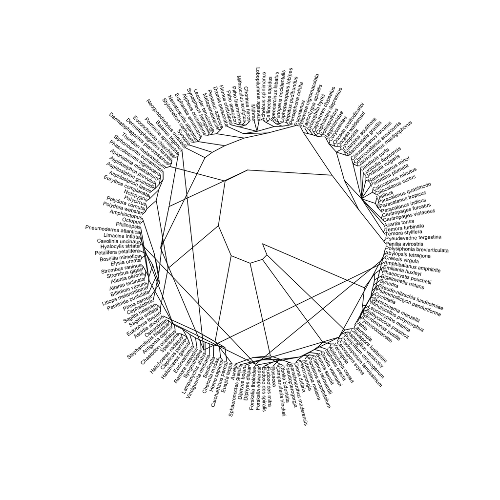

```r
#Error: HTTP failure: 400 The following OTT ids were not found:
#  [5264367, 632176, 621380, 67823, 955367, 588763, 566119, 3634672, 1083518, 2841628]
#Dropping singleton nodes with labels:
#  Amphibalanus ott1042709, Creseis ott671266, Abylopsis ott4718809, Polysiphonia ott674045

plot(tr, 'radial', font = 1, cex = 0.5)
```

```r
phylowidget(tr)
```

[interactive chart not shown]